# Loomis Ideal Body Proportions

An investigation of the artistic ideal versus actual body proportions

## Introduction

Andrew Loomis was a well known and influential art instructor in the mid 20th century. He authored a series of drawing manuals describing how to accurately depict the human body. Loomis proposed that to draw a male or female subject accurately, the artist should divide the figure into 8 sections, each approximately the length of the individual’s head. This project summary is a brief exploration of the ideal body proportions proposed by Loomis through analysis of anatomic measurements.

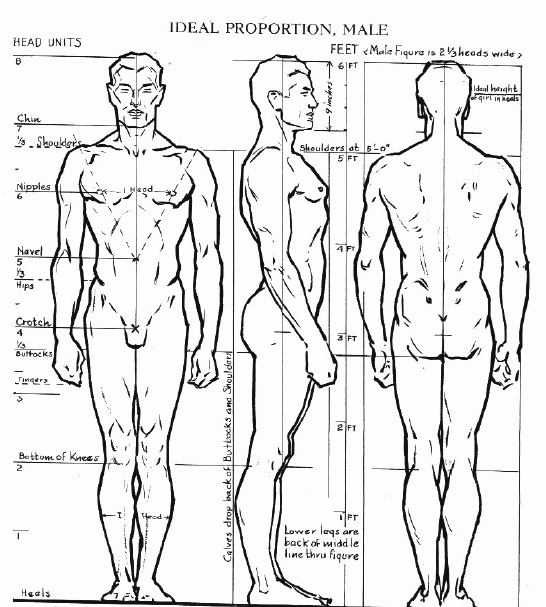

Excerpt from ‘Figure Drawing for All it's Worth’ by Andrew Loomis (1943) )

## Preprocessing

The dataset is composed of measurements from 251 volunteers ranging in age from 1 to 94 years old. Since body proportions change throughout childhood, data points from volunteers under 18 years of age are eliminated. Loomis maintained that the same ratio applied to both males and females, so participants from both genders were included.

```
##      height head.height head.circumference arm.span floor.navel hand.length
## 1  59.88189    9.055118                 NA 58.34646          NA    6.692913
## 4  64.56693    9.055118                 NA 61.02362          NA    6.692913
## 5  71.25984   10.236220                 NA 72.04724          NA    7.874016
## 7  60.74803    8.858268                 NA 59.09449          NA    6.771654
## 9  67.99213    7.874016                 NA 60.62992          NA    7.086614
## 10 64.56693    9.055118                 NA 60.74803          NA    6.692913
##    hand.width hand.elbow elbow.armpit arm.reach foot.length floor.kneepit
## 1    7.165354   13.70079     8.937008  74.09449    8.425197      14.76378
## 4    7.480315   15.35433    11.417323  79.52756    9.055118      15.35433
## 5    9.448819   16.92913    11.023622  90.94488    9.842520      16.53543
## 7    7.322835   14.52756     9.842520  59.09449    8.740157      15.15748
## 9    5.511811   15.15748     7.874016  14.96063   10.236220      17.71654
## 10   7.480315   15.23622    10.905512  79.17323    9.173228      15.15748
##    floor.hip floor.armpit
## 1   34.64567     48.22835
## 4   34.64567     50.00000
## 5   38.97638     56.69291
## 7   35.23622     48.03150
## 9   37.79528     53.14961
## 10  34.64567     50.00000
```

It looks like there are some NAs, and to evaluate data integrity, we should find out how much of the data is missing. For this analysis, volunteers were instructed to only submit measurements they were comfortable taking. It wouldn’t be appropriate to omit an entire row because someone couldn’t measure their head circumference or didn’t want to add their race. We won’t remove the rows with NAs, but it’s still good to know what percentage of the attributes are missing.

```
##       height head.height head.circumference arm.span floor.navel hand.length
## women   0.04        0.04               0.08     0.05        0.21        0.05
## men     0.04        0.03               0.06     0.03        0.18        0.03
##       hand.width hand.elbow elbow.armpit arm.reach foot.length floor.kneepit
## women       0.06       0.09         0.09      0.09        0.09          0.09
## men         0.11       0.07         0.08      0.08        0.06          0.06
##       floor.hip floor.armpit
## women      0.10         0.09
## men        0.15         0.06
```

Next we need to identify and eliminate anomalous data points that may skew the results. These outliers are defined as any measurement with a z score of three or higher. The z score represents the number of standard deviations a data point is from the mean. Because there is an inherent variation in size across genders, the data will need to be partitioned before calculating mean and standard deviation.

```
## 15 rows containing outliers were removed.
```

## Exploratory Data Analysis

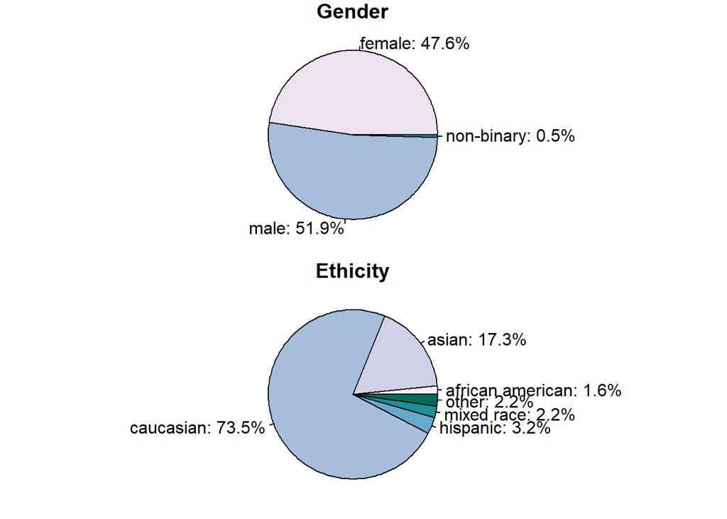

Histograms that show the distribution of the deviation from the ideal standard head height to body height ratio proposed by Loomis.

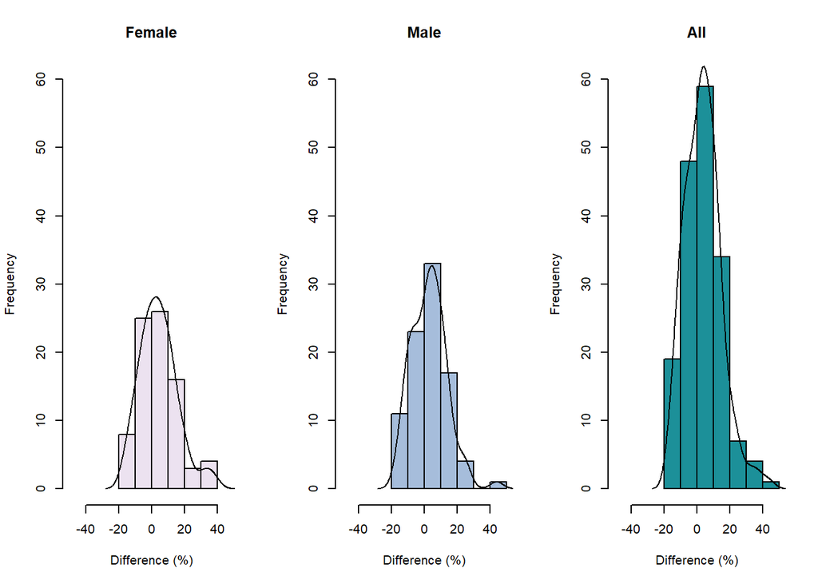

There doesn’t appear to be much difference between genders, but we can do a t test to confirm that hypothesis.

```
##
##  Welch Two Sample t-test
##
## data:  sub$ratio[sub$gender == "male"] and sub$ratio[sub$gender == "female"]
## t = -0.78014, df = 164.38, p-value = 0.4364
## alternative hypothesis: true difference in means is not equal to 0
## 95 percent confidence interval:
##  -0.007433016  0.003222809
## sample estimates:
## mean of x mean of y
## 0.1306759 0.1327810
```

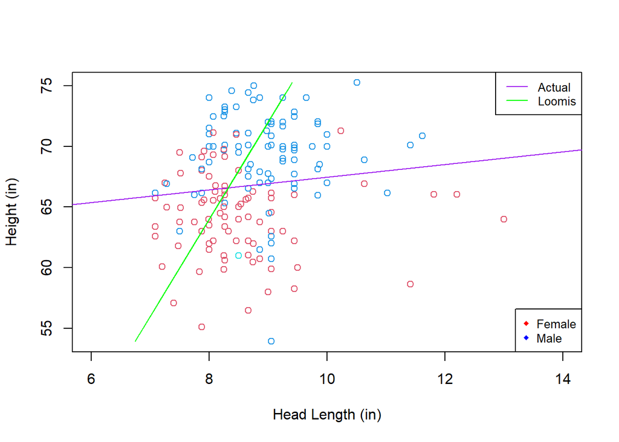

A correlation matrix can be used to evaluate the linear dependence between attributes. In the heatmap below, red is used for a highly correlated attributes, and blue for data points with much lower evidence of dependency.

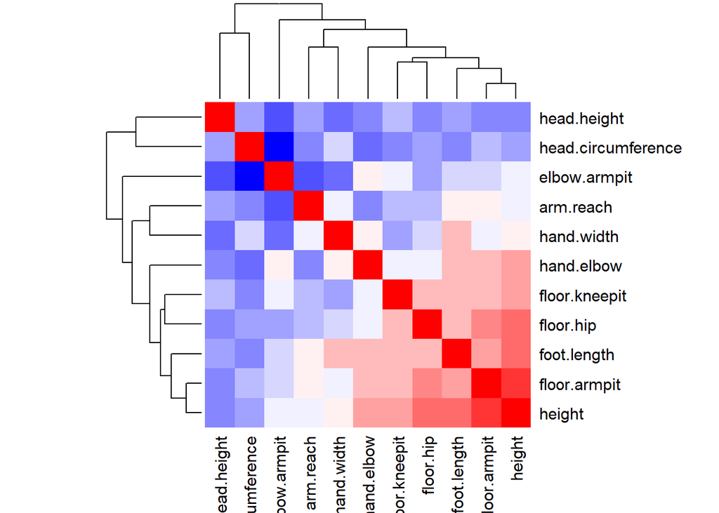

```
## Correlation matrix:
```

```
##                height head.height
## height      1.0000000   0.1312089
## head.height 0.1312089   1.0000000
```

## Findings

The strongest positive correlation between measurements was the underarm height and overall height. Head height, however, was not shown to be dependent on total height. Out of all the data points, 68% were found to fall within +/- 10% of Loomis’s ideal .125 ratio. The mean value from the sample data set was shown to be ~.132, and no significant difference in head to height ratio was observed across genders. Close to 70% of the volunteers in this study fell within 10% of Loomis’s ideal body proportions when comparing head height to total body height.